# WHICH philosophy schools are widly accpeted by others and WHY?

## INTRODUCTION

No matter what fields we are in, as long as there are different schools, there are competitions and cooperation, like policy, artistry, and wizarding. Also, when coming to a particular science field, some theories of a certain school are more widely accepted by others while some remain controversial. For example, relativity theory is hardly rejected, while whether there are parallel universes remains a myth.

#### So intuitively, I'm wondering are there schools that are more acceptable to all the other schools?

#### If there are, why?

```python
import warnings
warnings.simplefilter(action='ignore', category=FutureWarning)

import numpy as np
import pandas as pd
import seaborn as sns
import matplotlib.pyplot as plt
import pyLDAvis

#from sklearn.ensemble import RandomForestClassifier
#from sklearn.model_selection import cross_val_score
#from sklearn.model_selection import train_test_split
from PIL import Image
#from wordcloud import WordCloud, STOPWORDS, ImageColorGenerator


sns.set_theme()

%matplotlib inline


import sys
sys.path.insert(0, '../lib')

import PS
import AU
import LDA
import WD
```

```python
df = pd.read_csv('../data/philosophy_data.csv', header=0, parse_dates=True)
```

```python
df.info()
```

```
<class 'pandas.core.frame.DataFrame'>
RangeIndex: 360808 entries, 0 to 360807
Data columns (total 11 columns):
 #   Column                     Non-Null Count   Dtype
---  ------                     --------------   -----
 0   title                      360808 non-null  object
 1   author                     360808 non-null  object
 2   school                     360808 non-null  object
 3   sentence_spacy             360808 non-null  object
 4   sentence_str               360808 non-null  object
 5   original_publication_date  360808 non-null  int64
 6   corpus_edition_date        360808 non-null  int64
 7   sentence_length            360808 non-null  int64
 8   sentence_lowered           360808 non-null  object
 9   tokenized_txt              360808 non-null  object
 10  lemmatized_str             360808 non-null  object
dtypes: int64(3), object(8)
memory usage: 30.3+ MB
```

## Methodology

### ✨Which are popular

#### Q: Attitude of a school towards others?

A: Calculate the proportion of positive attitude of each school article towards other schools' names and authors.

#### Q: Frequency of a school mentioned by others?

A: Calculate the frequency of each school's article mentioning other school name and their authors.

### ✨Why are they

#### Q: Talking about?

A: Classify topics mentioned by certain schools.

```python
p = PS.philosophy_sentiment(df)
attitude_matrix,freq_matrix = p.matrix()
display(attitude_matrix)
display(freq_matrix)
```

```
2022-02-02 10:49:53,746 loading file /Users/rong/.flair/models/sentiment-en-mix-distillbert_4.pt
plato
aristotle
empiricism
rationalism
analytic
continental
phenomenology
german_idealism
communism
capitalism
stoicism
nietzsche
feminism
```

|  | plato_act | aristotle_act | empiricism_act | rationalism_act | analytic_act | continental_act | phenomenology_act | german_idealism_act | communism_act | capitalism_act | stoicism_act | nietzsche_act | feminism_act |
| --- | --- | --- | --- | --- | --- | --- | --- | --- | --- | --- | --- | --- | --- |
| plato | 0.077520 | 0.174184 | -0.183783 | 0.076737 | 0.068534 | 0.277484 | 0.488648 | 0.145477 | 0.227179 | 0.570620 | 0.268885 | 0.174635 | 0.364163 |
| aristotle | 0.000000 | 0.000000 | 0.009824 | -0.031570 | -0.115621 | 0.180606 | 0.382768 | 0.181529 | -0.163420 | 0.447433 | 0.000000 | 0.408546 | 0.224356 |
| empiricism | 0.000000 | 0.000000 | 0.360136 | -0.577102 | 0.177645 | 0.205396 | 0.089793 | 0.096760 | 0.254731 | 0.104634 | 0.000000 | 0.818225 | 0.208275 |
| rationalism | 0.000000 | 0.000000 | 0.293412 | 0.083246 | 0.318841 | 0.252160 | 0.385916 | 0.333752 | 0.467915 | 0.000000 | 0.000000 | 0.039943 | 0.137432 |
| analytic | 0.916564 | 0.064642 | 0.000000 | 0.902450 | -0.045653 | 0.161962 | 0.212265 | 0.123738 | 0.756634 | 0.298094 | 0.000000 | 0.000000 | 0.231785 |
| continental | 0.000000 | 0.000000 | 0.000000 | 0.000000 | -0.994393 | 0.223232 | 0.000000 | 0.000000 | -0.129242 | 0.953969 | 0.000000 | 0.000000 | 0.000000 |
| phenomenology | 0.000000 | 0.000000 | 0.000000 | 0.000000 | 0.361367 | 0.159409 | 0.344290 | -0.308148 | 0.000000 | 0.000000 | 0.000000 | 0.000000 | -0.500544 |
| german_idealism | 0.000000 | 0.000000 | 0.000000 | 0.000000 | 0.496599 | 0.361268 | 0.477549 | 0.320230 | 0.285655 | 0.000000 | 0.000000 | 0.168772 | 0.328911 |
| communism | 0.000000 | 0.707944 | 0.000000 | 0.000000 | 0.727292 | 0.275170 | 0.436214 | 0.000000 | 0.088436 | 0.240485 | 0.000000 | 0.000000 | 0.345209 |
| capitalism | 0.000000 | 0.000000 | 0.000000 | 0.000000 | -0.255592 | 0.178620 | 0.999335 | 0.251053 | 0.099687 | -0.314223 | 0.000000 | 0.000000 | -0.267959 |
| stoicism | 0.000000 | 0.000000 | 0.000000 | 0.725248 | 0.000000 | 0.000000 | 0.000000 | 0.000000 | 0.000000 | 0.999328 | -0.188119 | 0.940569 | 0.992525 |
| nietzsche | 0.000000 | 0.000000 | 0.000000 | 0.000000 | 0.000000 | 0.352224 | 0.306912 | 0.000000 | 0.000000 | 0.000000 | 0.000000 | 0.850632 | 0.638088 |
| feminism | 0.000000 | 0.000000 | 0.000000 | 0.000000 | 0.985776 | 0.000000 | 0.997239 | 0.000000 | 0.000000 | 0.000000 | 0.000000 | 0.000000 | -0.040777 |

|  | plato_act | aristotle_act | empiricism_act | rationalism_act | analytic_act | continental_act | phenomenology_act | german_idealism_act | communism_act | capitalism_act | stoicism_act | nietzsche_act | feminism_act |
| --- | --- | --- | --- | --- | --- | --- | --- | --- | --- | --- | --- | --- | --- |
| plato | 30 | 74 | 10 | 38 | 45 | 163 | 64 | 58 | 8 | 6 | 7 | 49 | 31 |
| aristotle | 0 | 0 | 4 | 168 | 107 | 37 | 77 | 36 | 11 | 5 | 0 | 7 | 10 |
| empiricism | 0 | 0 | 5 | 1 | 285 | 75 | 163 | 65 | 16 | 13 | 0 | 4 | 3 |
| rationalism | 0 | 0 | 12 | 204 | 102 | 355 | 278 | 151 | 5 | 0 | 0 | 20 | 5 |
| analytic | 1 | 2 | 0 | 2 | 1524 | 192 | 145 | 200 | 4 | 3 | 0 | 0 | 18 |
| continental | 0 | 0 | 0 | 0 | 1 | 215 | 0 | 0 | 5 | 2 | 0 | 0 | 0 |
| phenomenology | 0 | 0 | 0 | 0 | 3 | 327 | 239 | 3 | 0 | 0 | 0 | 0 | 5 |
| german_idealism | 0 | 0 | 0 | 0 | 91 | 373 | 384 | 361 | 12 | 0 | 0 | 56 | 21 |
| communism | 0 | 1 | 0 | 0 | 1 | 100 | 7 | 0 | 375 | 6 | 0 | 0 | 23 |
| capitalism | 0 | 0 | 0 | 0 | 113 | 227 | 1 | 5 | 347 | 155 | 0 | 0 | 36 |
| stoicism | 0 | 0 | 0 | 3 | 0 | 0 | 0 | 0 | 0 | 1 | 5 | 1 | 2 |
| nietzsche | 0 | 0 | 0 | 0 | 0 | 220 | 118 | 0 | 0 | 0 | 0 | 4 | 13 |
| feminism | 0 | 0 | 0 | 0 | 2 | 0 | 1 | 0 | 0 | 0 | 0 | 0 | 27 |

## Findings from Attitude heatmap

### Explanation

Columns: Attitudes of a school towards other schools\ Rows : How a school is mentioned by other schools

- In "**attitude_matrix**"

higher scored = positive attitude, lower scored = negative attitude\ higher scores = positive attitude, lower scores = negative attitude

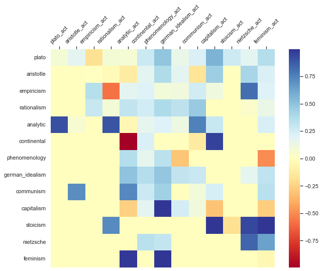

```python
sns.set(rc={'figure.figsize':(10,8)})
att = sns.heatmap(attitude_matrix, annot=False,cmap ="RdYlBu")#
att.set_xticklabels(att.get_xticklabels(),rotation=45)
att.xaxis.set_ticks_position("top")
None
```

#### 🕶 Continental school is strongly against by Analytic school.

"So analytic philosophy is concerned with analysis – analysis of thought, language, logic, knowledge, mind, etc; whereas continental philosophy is concerned with synthesis – synthesis of modernity with history, individuals with society, and speculation with application."\ -- Kile Jones

https://philosophynow.org/issues/74/Analytic_versus_Continental_Philosophy#:~:text=So%20analytic%20philosophy%20is%20concerned,society%2C%20and%20speculation%20with%20application

"The disagreement between rationalism and empiricism primarily concerns the second question, regarding the sources of our concepts and knowledge. In some instances, the disagreement on this topic results in conflicting responses to the other questions as well. The disagreement may extend to incorporate the nature of warrant or where the limits of our thought and knowledge are."\ -- Peter Markie

https://plato.stanford.edu/entries/rationalism-empiricism/

#### 🕶 Feminism school is going against the phenomenology school.

"Phenomenology and feminism are rarely associated, either in or out of the context of film studies. The reasons for this disjunction are strikingly obvious at first glance. The former stands as a paragon of male philosophical observation. The latter proclaims its interest in transforming an oppressive system rather than being content with interpreting it If philosophical reflection must achieve a polite distanciation from its object of study, the notion of a feminist revolutionary philosophy certainly must be perceived as an oxymoron." -- Gaylyn Studlar

https://www.tandfonline.com/doi/abs/10.1080/10509209009361353?journalCode=gqrf20

#### 🕶 Capitalism school is controversial.

"Critics argue that capitalism is associated with the unfair distribution of wealth and power; a tendency toward market monopoly or oligopoly (and government by oligarchy); imperialism, counter-revolutionary wars and various forms of economic and cultural exploitation; repression of workers and trade unionists and phenomena such as social alienation, economic inequality, unemployment and economic instability. " -- wiki

## Findings from Frequency heatmap

Before combing the results of frequency result and attitude result, we go through the frequency heatmap first to see whether there are interesting finds.

### Explanation

Columns: Frequencies of a school mention other schools\ Rows : How often a school is mentioned by other schools

- In "**freq_matrix**"

higher scored = frequently cited, lower scored = rarely cited\ higher scores = frequently cites, lower scores = rarely cites

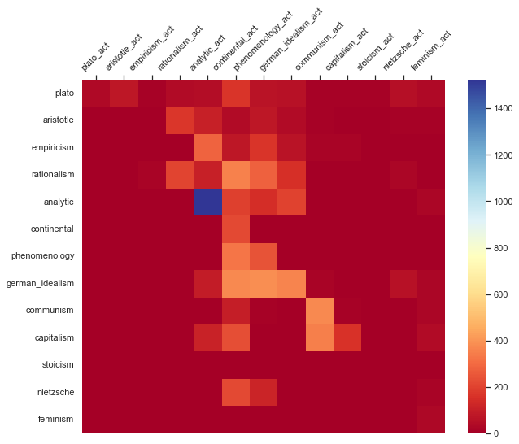

```python
freq = sns.heatmap(freq_matrix, annot=False,cmap ="RdYlBu")
freq.set_xticklabels(freq.get_xticklabels(),rotation=45)
freq.xaxis.set_ticks_position("top")
```

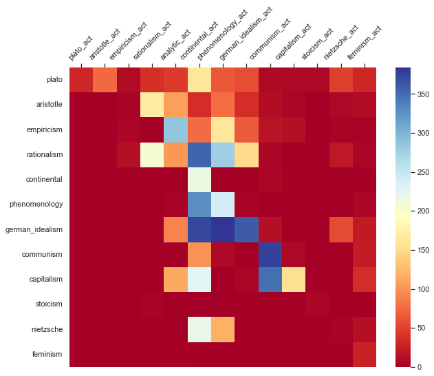

```python
freq_matrix_other = freq_matrix.drop('analytic')
freq_o = sns.heatmap(freq_matrix_other, annot=False,cmap ="RdYlBu")
freq_o.set_xticklabels(freq_o.get_xticklabels(),rotation=45)
freq_o.xaxis.set_ticks_position("top")
```

#### 🕶 Analytic scholars pretty like to cite their counterparts.

Actually, is "the" counterpart Russell.

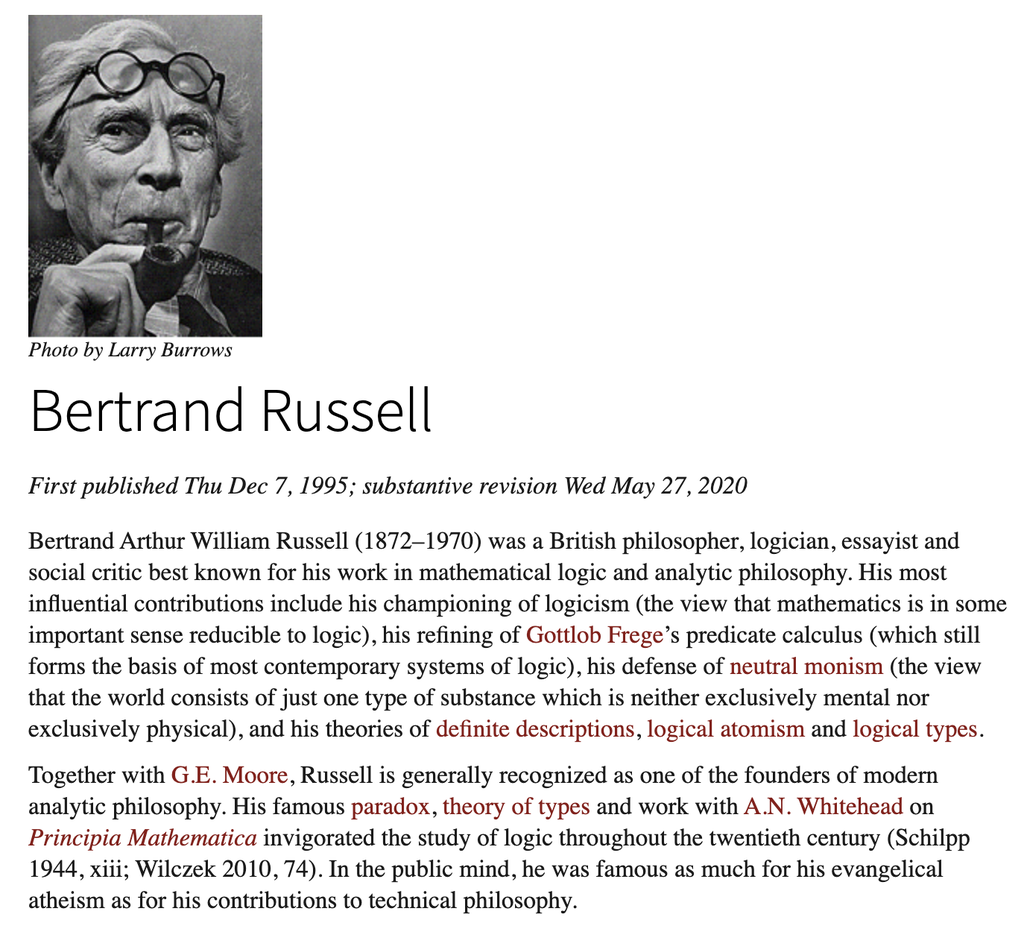

```python
from IPython.display import Image
Image(filename='../figs/Russell.png',width = 600, height = 300)
```

```python
A = AU.author_analysis(df)
au_analytic = A.popular_author('analytic','analytic')
au_analytic
```

```
2022-02-02 11:58:49,353 loading file /Users/rong/.flair/models/sentiment-en-mix-distillbert_4.pt
```

|  | school | author | Citation_times |
| --- | --- | --- | --- |
| 0 | analytic | Russell | 632 |
| 4 | analytic | Quine | 217 |
| 3 | analytic | Lewis | 125 |
| 1 | analytic | Moore | 87 |
| 2 | analytic | Wittgenstein | 75 |
| 6 | analytic | Kripke | 40 |
| 5 | analytic | Popper | 5 |

#### 🕶 German_idealism is highly cited by continental, phenomenology and german_idealism.

Can this also be a certain author's contribution?\ It's hard to say. Since the topic is focusing more on the school, we can discuss authors afterward. So here we show the result, but not go further with it.

```python
A = AU.author_analysis(df)
au_analytic_list = df['author'][df.school == 'german_idealism'].drop_duplicates().reset_index(drop = 'True')
german_au = pd.DataFrame(columns = ["Citation_times"])
for au in au_analytic_list:
    res = A.the_author(au)
    german_au.loc[au]= sum(res.loc['Citation_times'])
german_au.sort_values('Citation_times',ascending = False)
```

```
2022-02-02 11:58:56,823 loading file /Users/rong/.flair/models/sentiment-en-mix-distillbert_4.pt
```

|  | Citation_times |
| --- | --- |
| Kant | 792 |
| Hegel | 483 |
| Fichte | 59 |

#### 🕶 Plato and Rationalism are widely cited.

Plato is continuously mentioned over time. Descartes is famous. Also, if you are interested in them welcome back afterward.

```python
A = AU.author_analysis(df)
au_plato_list = df['author'][df.school == 'plato'].drop_duplicates().reset_index(drop = 'True')
PR_au = pd.DataFrame(columns = ["school","Citation_times"])
for au in au_plato_list:
    res = A.the_author(au)
    PR_au.loc[au]= ['plato',sum(res.loc['Citation_times'])]

au_ration_list = df['author'][df.school == 'rationalism'].drop_duplicates().reset_index(drop = 'True')
for au in au_ration_list:
    res = A.the_author(au)
    PR_au.loc[au]= ['rationalism',sum(res.loc['Citation_times'])]
PR_au.sort_values('Citation_times',ascending = False)
```

```
2022-02-02 12:00:46,343 loading file /Users/rong/.flair/models/sentiment-en-mix-distillbert_4.pt
```

|  | school | Citation_times |
| --- | --- | --- |
| Descartes | rationalism | 671 |
| Plato | plato | 558 |
| Leibniz | rationalism | 209 |
| Spinoza | rationalism | 144 |
| Malebranche | rationalism | 48 |

## Findings from Attitude and Frequency matrix

#### ✨Here comes the most exciting parts! Let's try to find the popular star!

```python
pro_approve = attitude_matrix.to_numpy()
pro_mentioned = freq_matrix.to_numpy()
X,Y = [],[]
for i in range(len(pro_approve)):
    x = round(np.sum(np.array(pro_approve[i]) >= 0, axis=0)/len(pro_approve[i]),2)
    y = sum(pro_mentioned[i]) - pro_mentioned[i][i]
    X.append(x)
    Y.append(y)
Att = pd.DataFrame(index = attitude_matrix.index)
Att['Posstive rate'] = X
Att['Citation times'] = Y
Att.sort_values(['Citation times','Posstive rate'],ascending = False)
```

|  | Posstive rate | Citation times |
| --- | --- | --- |
| german_idealism | 1.00 | 937 |
| rationalism | 1.00 | 928 |
| capitalism | 0.77 | 729 |
| empiricism | 0.92 | 625 |
| analytic | 0.92 | 567 |
| plato | 0.92 | 553 |
| aristotle | 0.77 | 462 |
| nietzsche | 1.00 | 351 |
| phenomenology | 0.85 | 338 |
| communism | 1.00 | 138 |
| continental | 0.85 | 8 |
| stoicism | 0.92 | 7 |
| feminism | 0.92 | 3 |

## What does these two school talking about?

Here are two versions of each of them. One is from the philosophy scholars and the other one is from algorithm analysis.

### 👑 German idealism

#### SCHOLARS conclusion:

"Knowledge is constituted by the sensible contents derived from the object of cognition and the a priori forms in the faculties of the mind. Thus, things considered in themselves, apart from the way mind organizes sensible contents, are in principle unknowable. With this argument, God and the soul became inaccessible because they do not exhibit sensible content. While Kant rejected the epistemological possibility of knowing God, he affirmed the possibility of knowledge in the realm of morality. Nevertheless, Kant relegated various theological concepts such as God and the immortality of soul from the realm of knowledge."

#### ALGORITHM conclusion:

- Topic I: Existence of world is abstract.
- Topic II: Ethical law of human and self consciousness.
- Topic III: Relationship between self consciousness, nature essence, and universal recognition.

```python
LDA_ger = LDA.LDA_phil(df,'german_idealism')#.LDA_phil
germ_df = LDA_ger.process()
pyLDAvis.display(germ_df)
```

```
Building dictionary...
Building corpus...
```

[interactive chart not shown]

### 👑 Rationalism

#### SCHOLARS conclusion:

"Rationalism, in Western philosophy, is the view that regards reason as the chief source and test of knowledge. Holding that reality itself has an inherently logical structure, the rationalist asserts that a class of truths exists that the intellect can grasp directly. There are, according to the rationalists, certain rational principles—especially in logic and mathematics, and even in ethics and metaphysics—that are so fundamental that to deny them is to fall into contradiction. Rationalism is the epistemological view that "regards reason as the chief source and test of knowledge" or "any view appealing to reason as a source of knowledge or justification". More formally, rationalism is defined as a methodology or a theory "in which the criterion of the truth is not sensory but intellectual and deductive"."

#### ALGORITHM conclusion:

- Topic 1: Human spirit and body motions.
- Topic 2: God, nature and knowledge.
- Topic 3: Vortexes between god and minds.

```python
LDA_ra = LDA.LDA_phil(df,'rationalism')
ration_df = LDA_ra.process()
pyLDAvis.display(ration_df)
```

```
Building dictionary...
Building corpus...
```

[interactive chart not shown]

# “We learn not philosophy, we learn to philosophize”

—— Kant